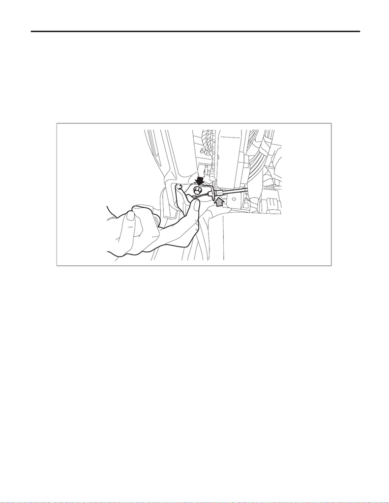

SL-56

Remote Openers

SECURITY AND LOCKS

17.Remote Openers

A: REMOVAL

1. FRONT HOOD OPENER

1) Remove the cover assembly - instrument panel LWR driver OUT. <Ref. to EI-61, REMOVAL, Instrument

Panel Lower Cover.>

2) Remove the cover side sill - front. <Ref. to EI-81, REMOVAL, Lower Inner Trim.>

3) Remove the opener handle.

(1) Remove the cable - front hood.

(2) Remove the bolt, and remove the opener handle.

4) Remove the mud guard - front LH. <Ref. to EI-23, REMOVAL, Mud Guard.>

5) Remove the lock assembly - front hood. <Ref. to SL-51, REMOVAL, Front Hood Lock Assembly.>

6) Attach a string to the end of cable - front hood, and remove the cable clip and cable - front hood.

NOTE:

Leave the string attached to the body, and use it during installation.

SL-01466

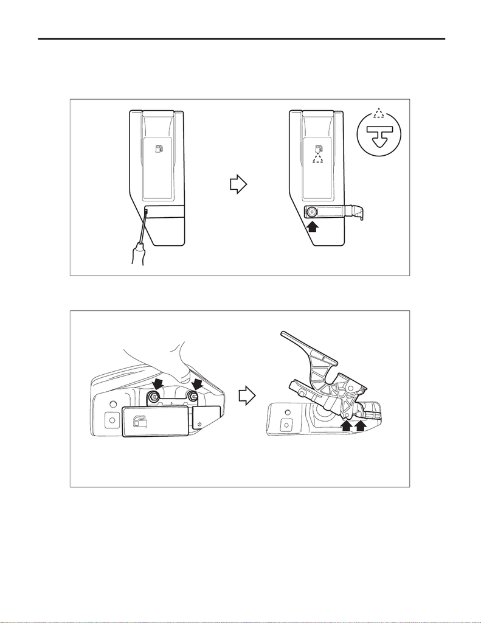

SL-57

Remote Openers

SECURITY AND LOCKS

2. FUEL FLAP OPENER

1) Remove the lower inner trim. <Ref. to EI-81, REMOVAL, Lower Inner Trim.>

2) Remove the cover - handle.

(1) Open the cover by using a flat tip screwdriver.

3) Remove the pull handle - opener.

(2) Remove the cable from pull handle - opener.

4) Remove the trim panel - trunk side RH. <Ref. to EI-95, REMOVAL, Trunk Room Trim.>

SL-02719

SL-02931

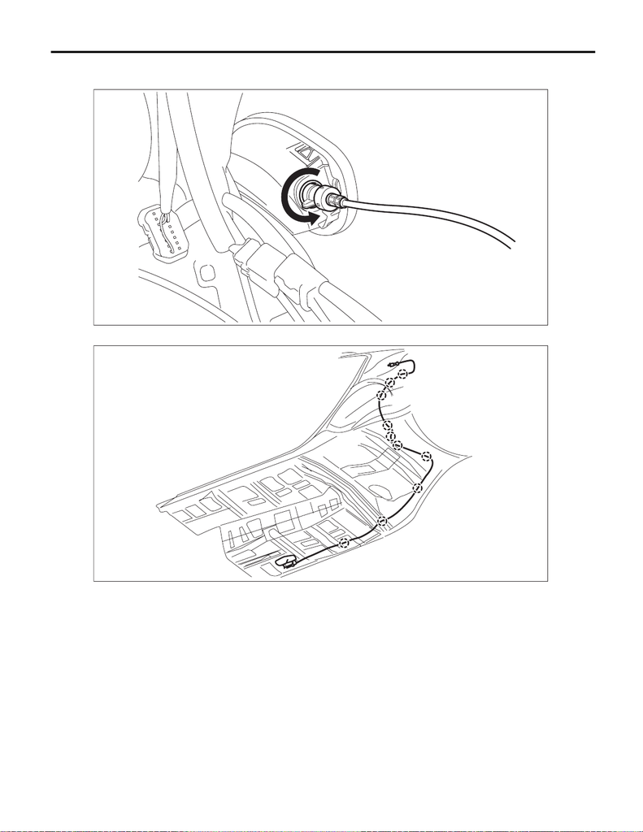

SL-58

Remote Openers

SECURITY AND LOCKS

5) Remove the cable assembly - fuel inside the quarter panel.

(1) Turn the cable assembly - fuel counterclockwise and pull toward vehicle rear.

6) Remove the cable clip, and remove the cable.

SL-02870

SL-01894

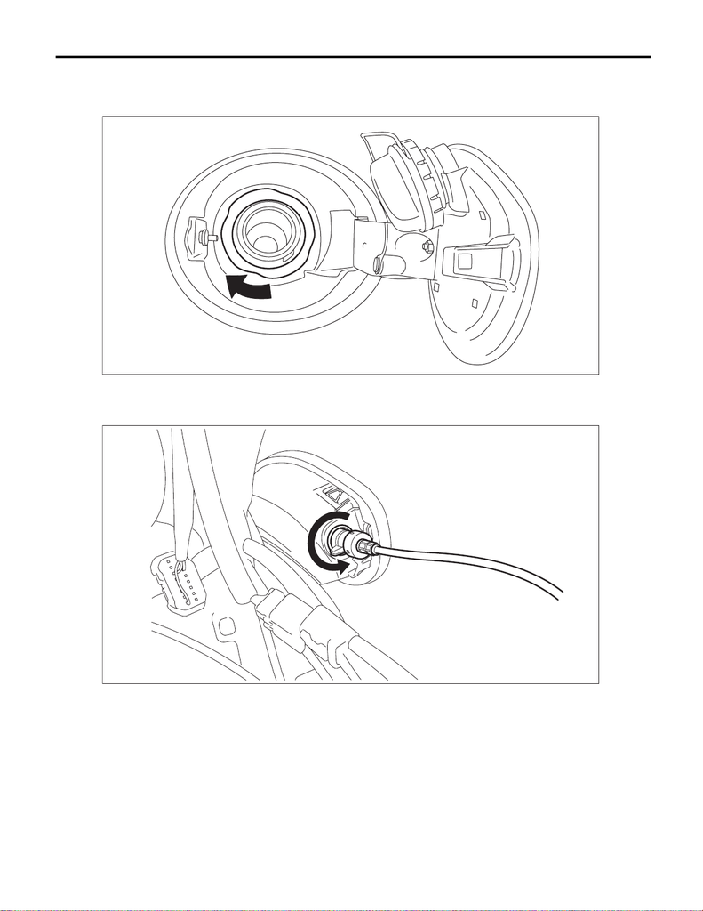

SL-59

Remote Openers

SECURITY AND LOCKS

3. FUEL FLAP

1) Open the fuel flap and remove the fuel filler cap.

2) Turn the fuel filler pipe protector in the direction of the arrow to unlock and remove it.

3) Remove the trim panel - trunk side RH. <Ref. to EI-95, REMOVAL, Trunk Room Trim.>

4) Remove the cable assembly - fuel inside the quarter panel.

(1) Turn the cable assembly - fuel counterclockwise and pull toward vehicle rear.

FU-08290

SL-02870

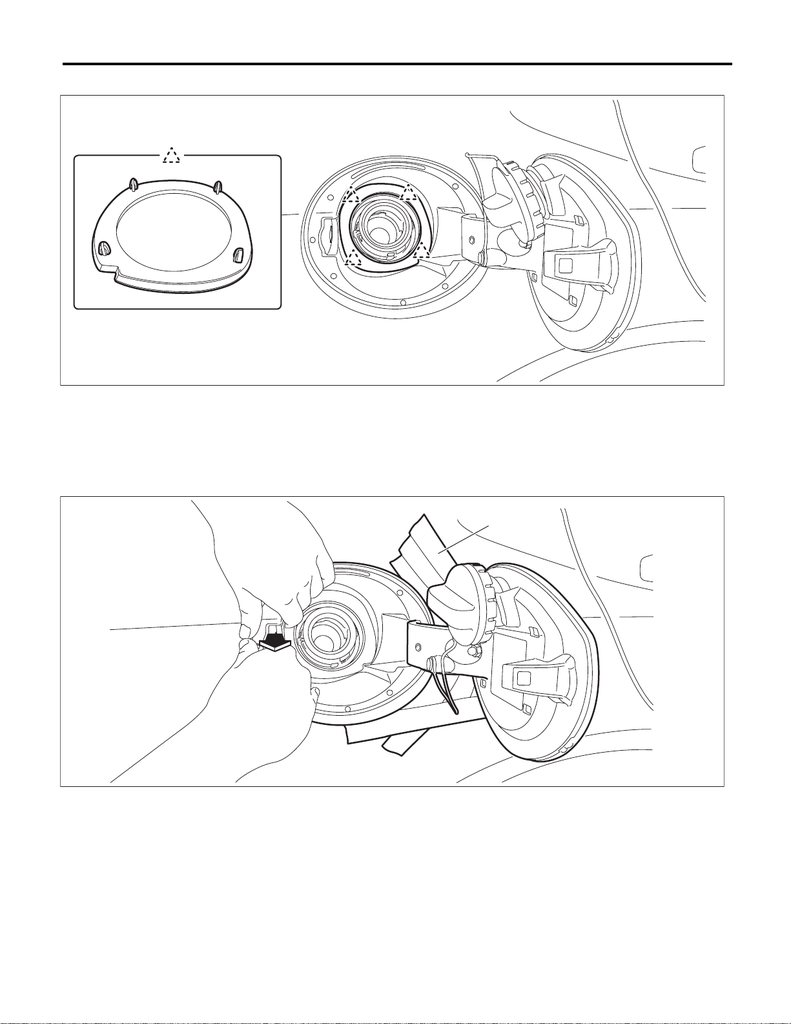

SL-60

Remote Openers

SECURITY AND LOCKS

5) Disconnect the ring clips.

6) Remove the saucer - COMPL.

CAUTION:

Be careful not to damage by forcibly prying at the rubber portion with a flat tip screwdriver or similar

tool.

(1) Attach the protective tape (A) to the panel side outer.

(2) Hold the position shown in the figure with your hands, release the claw and pull out toward yourself.

SL-02871

SL-02872

(A)

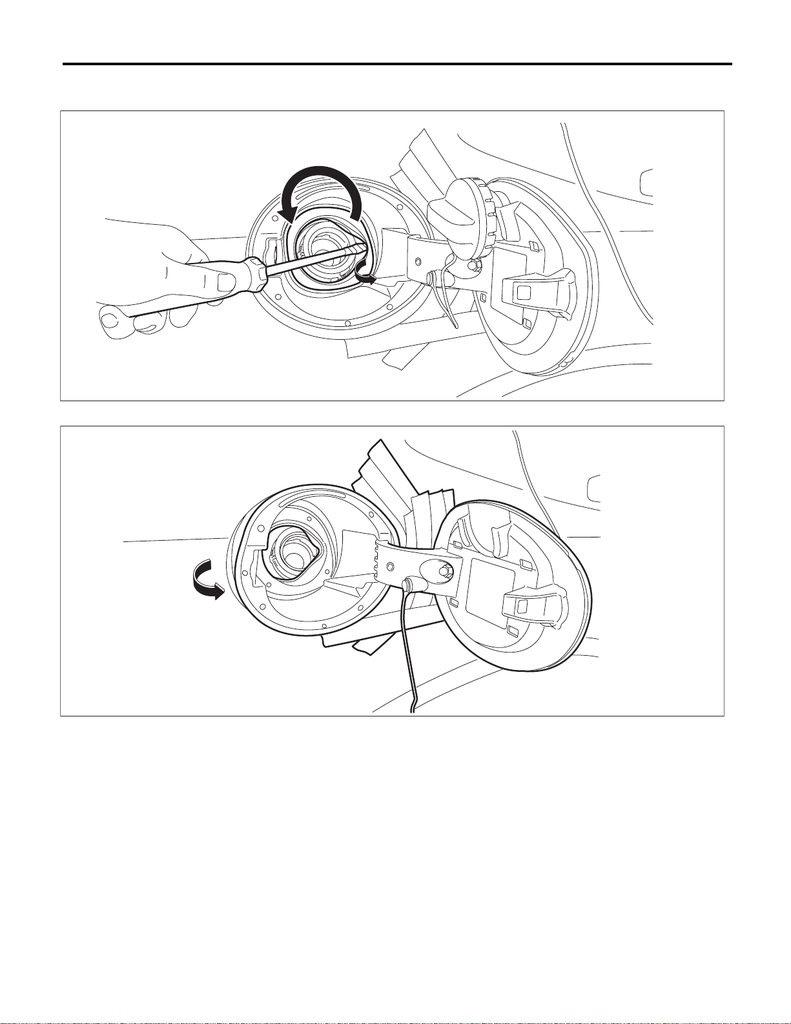

SL-61

Remote Openers

SECURITY AND LOCKS

(3) While pulling out toward yourself, remove the rubber portion from the fuel filler pipe using a flat tip

screwdriver or similar tool wrapped with a protection tape.

(4) Pull out while tilting toward the front of vehicle.

SL-02873

SL-02874

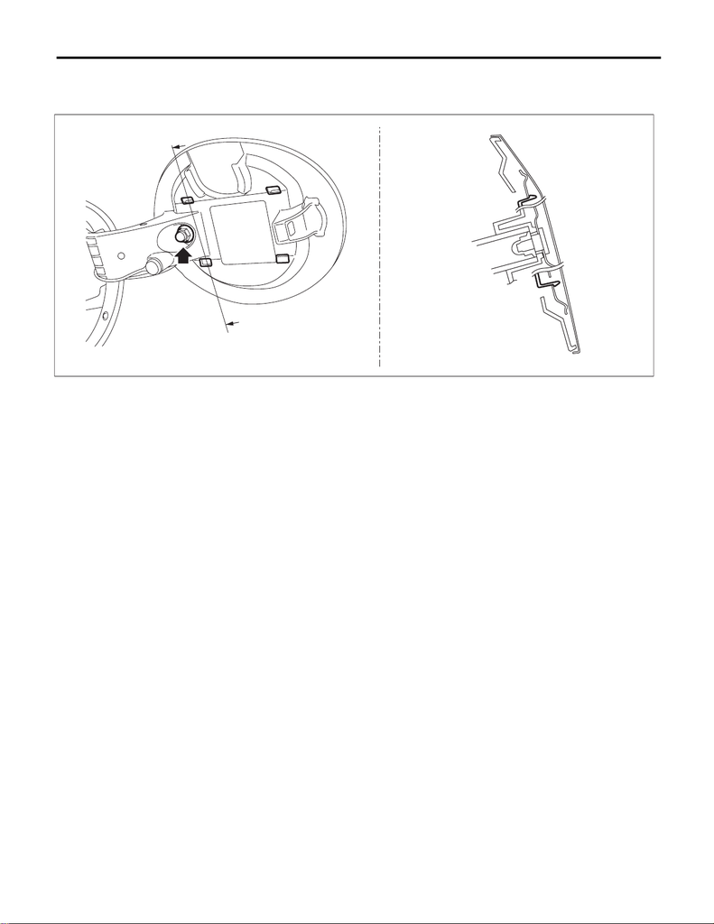

SL-62

Remote Openers

SECURITY AND LOCKS

7) Remove the flap - COMPL fuel from the saucer - COMPL.

(1) Remove the nut and release the claws using a flat tip screwdriver or similar tool wrapped with a pro-

tection tape.

B: INSTALLATION

1. FRONT HOOD OPENER

1) Before installation, check the following items.

• Cable is free from deformation such as fray.

2) Pull the string attached to the cable - front hood into the vehicle, and install the cable clip and cable - front

hood.

3) Install the lock assembly - front hood. <Ref. to SL-53, INSTALLATION, Front Hood Lock Assembly.>

4) Install the opener handle.

Tightening torque:

7.5 N·m (0.8 kgf-m, 5.5 ft-lb)

5) Install the cover side sill - front.

6) Install the cover assembly - instrument panel LWR driver OUT.

7) Install the mud guard - front LH.

2. FUEL FLAP OPENER

1) Install the cable assembly - fuel.

2) Install the pull handle - opener and cover - handle.

Tightening torque:

7.5 N·m (0.8 kgf-m, 5.5 ft-lb)

3) Install the trim panel - trunk side RH.

4) Install the lower inner trim.

SL-02875

A

A A-A

[figure not shown]

SL-63

Remote Openers

SECURITY AND LOCKS

3. FUEL FLAP

1) Install the flap - COMPL fuel to the saucer - COMPL.

Tightening torque:

7.5 N·m (0.8 kgf-m, 5.5 ft-lb)

2) Install the saucer - COMPL.

NOTE:

Securely install the rubber portion of the saucer - COMPL to the fuel filler pipe assembly.

3) Attach the ring clips.

4) Install the fuel filler pipe protector.

5) Install the cable assembly - fuel.

6) Install the trim panel - trunk side RH.

C: INSPECTION

Check if the front hood and fuel flap operate normally.